# Reproducible Pitch CO2 Uptake

23/07/2021

## Overview CO2 Uptake

This is a part of the Week4 Assignment to prepare a Shiny Application and a Reproducible Pitch

I have used the CO2 data available as part of R datasets. I have built a simple application which builds a basic lm model and predicts the CO2 uptake based on values chosen for ambient carbon dioxide concentrations, Plant unique identifier, Type or origin of the plant and Treatment.

The app is available in the link: https://karthikvmv.shinyapps.io/co2_uptake/

## Sample of CO2 Data

Below we have a sample of the CO2 data used in our assignment

```r
head(CO2)
```

```
  Plant   Type  Treatment conc uptake
1   Qn1 Quebec nonchilled   95   16.0
2   Qn1 Quebec nonchilled  175   30.4
3   Qn1 Quebec nonchilled  250   34.8
4   Qn1 Quebec nonchilled  350   37.2
5   Qn1 Quebec nonchilled  500   35.3
6   Qn1 Quebec nonchilled  675   39.2
```

## Explanation of the CO2 Shiny App

The following are the input sources

- a slider input for ambient CO2 concentrations. With values ranging from 90 to 1000 and default value of 100
- 3 radio buttons - one each for Plant, Type and Treatment
- Submit button to submit our choices We have two tabs
- one for the prediction (gives the predicted CO2 uptake value)
- one for plots(CO2 uptake against each of the features. Note: The predicted value is shown in the plot with CO2 uptake vs ambient CO2 concentrations)

## Plot CO2 Uptake vs Ambient CO2 Concentrations

This Ambient CO2 concentrations drives the CO2 Uptake values. Can be checked in the shiny app by changing the values.

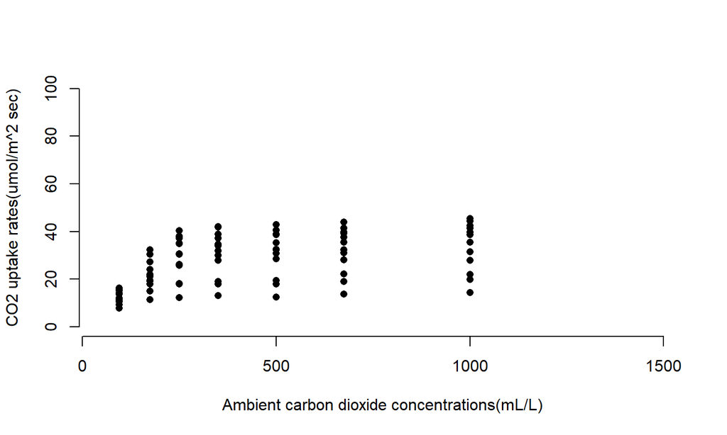